# Final Project - Practical Machine Learning

## Introduction

### From the Couse:

**Background**

Using devices such as Jawbone Up, Nike FuelBand, and Fitbit it is now possible to collect a large amount of data about personal activity relatively inexpensively. These type of devices are part of the quantified self movement – a group of enthusiasts who take measurements about themselves regularly to improve their health, to find patterns in their behavior, or because they are tech geeks. One thing that people regularly do is quantify how much of a particular activity they do, but they rarely quantify how well they do it. In this project, your goal will be to use data from accelerometers on the belt, forearm, arm, and dumbell of 6 participants. They were asked to perform barbell lifts correctly and incorrectly in 5 different ways. More information is available from the website here: http://web.archive.org/web/20161224072740/http:/groupware.les.inf.puc-rio.br/har (see the section on the Weight Lifting Exercise Dataset).

**Data**

The training data for this project are available here:

https://d396qusza40orc.cloudfront.net/predmachlearn/pml-training.csv

The test data are available here:

https://d396qusza40orc.cloudfront.net/predmachlearn/pml-testing.csv

The data for this project come from this source: http://web.archive.org/web/20161224072740/http:/groupware.les.inf.puc-rio.br/har. If you use the document you create for this class for any purpose please cite them as they have been very generous in allowing their data to be used for this kind of assignment.

## Downloading the data and load the libraries

```r
#path <- getwd()
#training_url <- "https://d396qusza40orc.cloudfront.net/predmachlearn/pml-training.csv"
#test_url <- "https://d396qusza40orc.cloudfront.net/predmachlearn/pml-testing.csv"

#download.file(training_url, destfile = paste(path, "pml-training.csv", sep = "/"))
#download.file(test_url, destfile = paste(path, "pml-testing.csv", sep = "/"))

training <- read.csv("pml-training.csv", na.strings=c("NA","#DIV/0!", ""))
testing <- read.csv("pml-testing.csv", na.strings=c("NA","#DIV/0!", ""))
```

```r
library("ggplot2")
library("dplyr")
library("randomForest")
library("caret")
```

The NaN was removed from the data sets. The index, factor columns and the *raw_timestamp_part_1* and *raw_timestamp_part_2* were removed

## Processing the data

```r
# set seed
set.seed(5)

# remove NAs
testing  <- testing [ ,  colSums(is.na(testing )) == 0]
training <- training[ , colSums(is.na(training)) == 0]

# remove index, name, and factor variables (for ease)
testing =   testing[-c(1,2,3,4,5,6)]
training = training[-c(1,2,3,4,5,6)]
```

## Feature Selection

It must be highlighted that there are other methods such as *Learning Vector Quantization* (LVQ) and *Recursive Feature Elimination* (RFE).

```r
correlationMatrix <- cor(training[,1:53])
highlyCorrelated <- findCorrelation(correlationMatrix,cutoff=0.70)
highlyCorrelated
```

```
##  [1] 11  2 10 23  5  4 37  9  3 38 36 39 22 35 24 26 14 49 47 46 34 19
```

```r
training <- training[,-highlyCorrelated]

dim(training)
```

```
## [1] 19622    32
```

The number of variables were reduced to 32.

## Patitioning the data

```r
inTrain <- createDataPartition(y=training$classe,p=0.7,list=FALSE)
training.training <- training[inTrain,]
training.testing <- training[-inTrain,]
```

## Fitting Model with Random Forests

It was created two different models, the first took into account the variables filtered from the *findCorrelation* with cutoff 0.70; The second model considered the most important features after implementing the *varImp* variable estimate.

## Model 1

```r
control <- trainControl(method="cv",allowParallel=TRUE)
modFit1 <- train(classe ~. ,data=training.training,method="rf",trControl=control)
```

```r
print(modFit1)
```

```
## Random Forest
##
## 13737 samples
##    31 predictor
##     5 classes: 'A', 'B', 'C', 'D', 'E'
##
## No pre-processing
## Resampling: Cross-Validated (10 fold)
## Summary of sample sizes: 12364, 12363, 12364, 12363, 12364, 12362, ...
## Resampling results across tuning parameters:
##
##   mtry  Accuracy   Kappa
##    2    0.9926475  0.9906991
##   16    0.9965062  0.9955807
##   31    0.9943952  0.9929100
##
## Accuracy was used to select the optimal model using the largest value.
## The final value used for the model was mtry = 16.
```

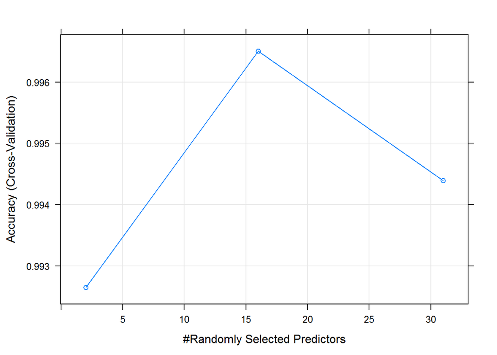

```r
plot(modFit1)
```

## Feature Selection - Part2

In this section was applied the estimate variable importance *varImp* to the model 1.

```r
# estimate variable importance
importance <- varImp(modFit1, scale=FALSE)
# summarize importance
print(importance)
```

```
## rf variable importance
##
##   only 20 most important variables shown (out of 31)
##
##                      Overall
## num_window            2880.4
## pitch_forearm          945.8
## magnet_dumbbell_z      841.3
## magnet_belt_y          781.5
## roll_dumbbell          584.6
## roll_forearm           522.9
## total_accel_dumbbell   396.1
## magnet_belt_x          313.3
## accel_forearm_z        307.9
## gyros_belt_z           303.6
## yaw_dumbbell           302.5
## roll_arm               254.5
## accel_forearm_x        231.1
## pitch_dumbbell         225.8
## magnet_forearm_z       213.0
## gyros_dumbbell_y       210.1
## magnet_arm_x           203.3
## gyros_belt_x           143.5
## magnet_forearm_y       122.5
## pitch_arm              121.2
```

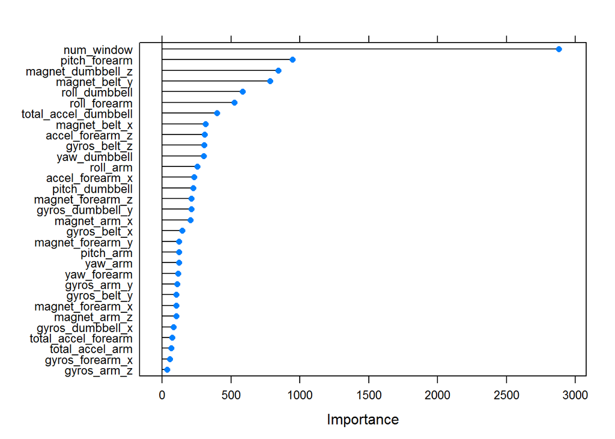

```r
# plot importance
plot(importance)
```

The most important features are: num_window, pitch_forearm, magnet_dumbbell_z, magnet_belt_y, and roll_dumbbell. Now the model 2 was created with these selected variables.

## Evaluation on test data - Model 1

The model 1 was evaluated using the splitted data.

```r
pred1 <- predict(modFit1,training.testing)
confusionMatrix(pred1,training.testing$classe)
```

```
## Confusion Matrix and Statistics
##
##           Reference
## Prediction    A    B    C    D    E
##          A 1674    1    0    0    0
##          B    0 1137    1    1    1
##          C    0    0 1024    0    0
##          D    0    0    1  963    0
##          E    0    1    0    0 1081
##
## Overall Statistics
##
##                Accuracy : 0.999
##                  95% CI : (0.9978, 0.9996)
##     No Information Rate : 0.2845
##     P-Value [Acc > NIR] : < 2.2e-16
##
##                   Kappa : 0.9987
##  Mcnemar's Test P-Value : NA
##
## Statistics by Class:
##
##                      Class: A Class: B Class: C Class: D Class: E
## Sensitivity            1.0000   0.9982   0.9981   0.9990   0.9991
## Specificity            0.9998   0.9994   1.0000   0.9998   0.9998
## Pos Pred Value         0.9994   0.9974   1.0000   0.9990   0.9991
## Neg Pred Value         1.0000   0.9996   0.9996   0.9998   0.9998
## Prevalence             0.2845   0.1935   0.1743   0.1638   0.1839
## Detection Rate         0.2845   0.1932   0.1740   0.1636   0.1837
## Detection Prevalence   0.2846   0.1937   0.1740   0.1638   0.1839
## Balanced Accuracy      0.9999   0.9988   0.9990   0.9994   0.9994
```

## Model 2

Creating new data sets using the top 5 most important variables.

```r
training.training2 <- subset(training.training, select = c("num_window", "pitch_forearm", "magnet_dumbbell_z", "magnet_belt_y", "roll_dumbbell", "classe"))

training.testing2 <- subset(training.testing, select = c("num_window", "pitch_forearm", "magnet_dumbbell_z", "magnet_belt_y", "roll_dumbbell", "classe"))
glimpse(training.testing2)
```

```
## Observations: 5,885
## Variables: 6
## $ num_window        <int> 12, 12, 12, 12, 12, 13, 13, 13, 13, 13, 13, ...
## $ pitch_forearm     <dbl> -63.8, -63.9, -63.9, -63.9, -63.9, -63.7, -6...
## $ magnet_dumbbell_z <dbl> -74, -68, -63, -72, -65, -72, -72, -60, -62,...
## $ magnet_belt_y     <int> 603, 598, 597, 607, 604, 601, 599, 606, 602,...
## $ roll_dumbbell     <dbl> 12.75083, 13.41048, 13.07949, 13.38246, 13.3...
## $ classe            <fct> A, A, A, A, A, A, A, A, A, A, A, A, A, A, A,...
```

## Fitting the model 2

```r
control <- trainControl(method="cv",allowParallel=TRUE)
modFit2 <- train(classe ~. ,data=training.training2,method="rf",trControl=control)
```

```r
print(modFit2)
```

```
## Random Forest
##
## 13737 samples
##     5 predictor
##     5 classes: 'A', 'B', 'C', 'D', 'E'
##
## No pre-processing
## Resampling: Cross-Validated (10 fold)
## Summary of sample sizes: 12363, 12362, 12362, 12364, 12364, 12364, ...
## Resampling results across tuning parameters:
##
##   mtry  Accuracy   Kappa
##   2     0.9949045  0.9935554
##   3     0.9958510  0.9947521
##   5     0.9950496  0.9937385
##
## Accuracy was used to select the optimal model using the largest value.
## The final value used for the model was mtry = 3.
```

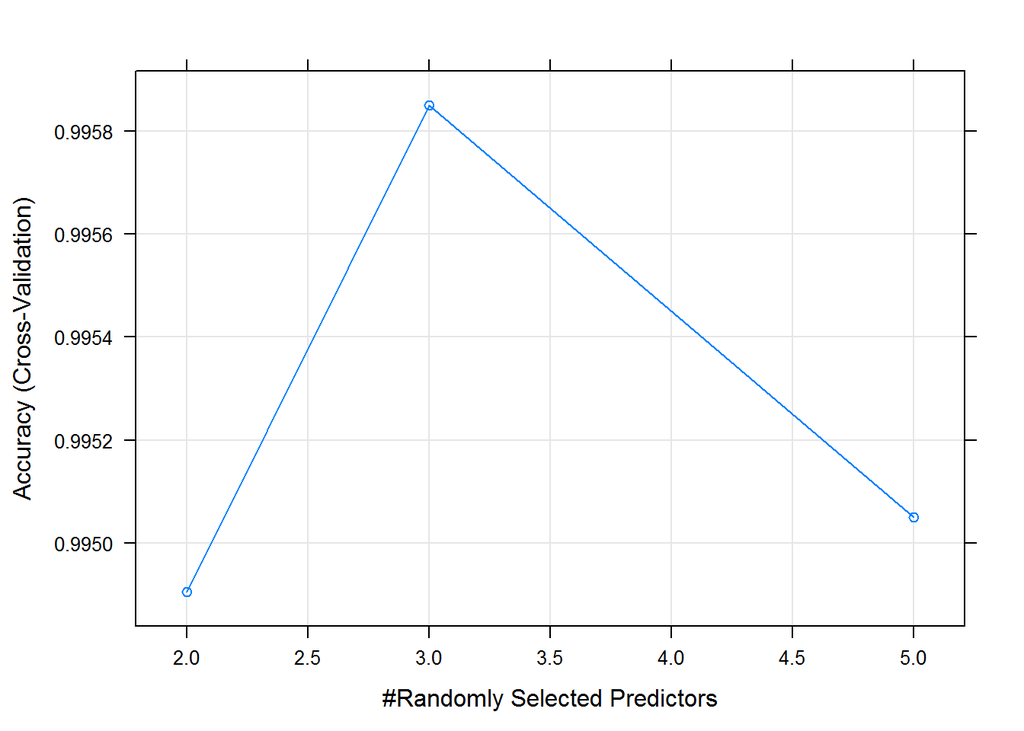

```r
plot(modFit2)
```

## Evaluation on test data - Model 2

```r
pred2 <- predict(modFit2,training.testing2)
confusionMatrix(pred2,training.testing2$classe)
```

```
## Confusion Matrix and Statistics
##
##           Reference
## Prediction    A    B    C    D    E
##          A 1673    3    0    0    0
##          B    0 1136    0    1    0
##          C    0    0 1026    0    0
##          D    0    0    0  961    3
##          E    1    0    0    2 1079
##
## Overall Statistics
##
##                Accuracy : 0.9983
##                  95% CI : (0.9969, 0.9992)
##     No Information Rate : 0.2845
##     P-Value [Acc > NIR] : < 2.2e-16
##
##                   Kappa : 0.9979
##  Mcnemar's Test P-Value : NA
##
## Statistics by Class:
##
##                      Class: A Class: B Class: C Class: D Class: E
## Sensitivity            0.9994   0.9974   1.0000   0.9969   0.9972
## Specificity            0.9993   0.9998   1.0000   0.9994   0.9994
## Pos Pred Value         0.9982   0.9991   1.0000   0.9969   0.9972
## Neg Pred Value         0.9998   0.9994   1.0000   0.9994   0.9994
## Prevalence             0.2845   0.1935   0.1743   0.1638   0.1839
## Detection Rate         0.2843   0.1930   0.1743   0.1633   0.1833
## Detection Prevalence   0.2848   0.1932   0.1743   0.1638   0.1839
## Balanced Accuracy      0.9993   0.9986   1.0000   0.9981   0.9983
```

# Predict on test data

## Model 1

```r
predictfinal1 <- predict(modFit1, testing)
predictfinal1
```

```
##  [1] B A B A A E D B A A B C B A E E A B B B
## Levels: A B C D E
```

## Model 2

```r
predictfinal2 <- predict(modFit2, testing)
predictfinal2
```

```
##  [1] B A B A A E D B A A B C B A E E A B B B
## Levels: A B C D E
```

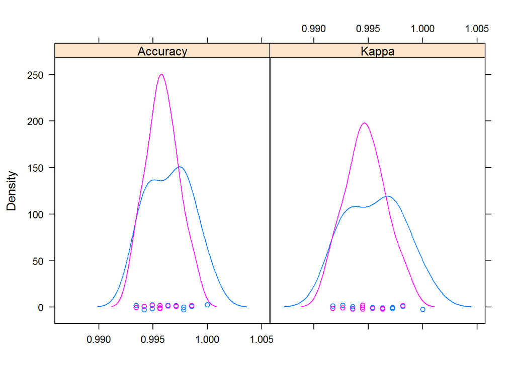

```r
results <- resamples(list(MODEL1=modFit1, MODEL2=modFit2))
densityplot(results)
```

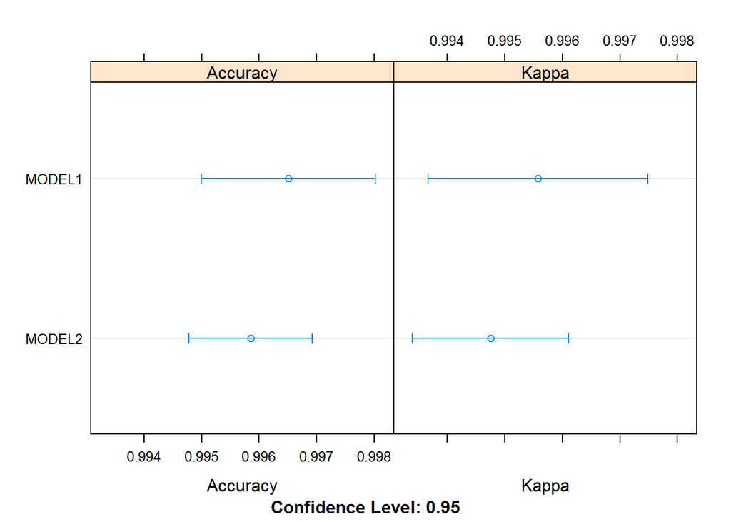

```r
dotplot(results)
```

The model selected is the **Model 2**. It presented lower overall accuracy with lower standard deviation when comparing to model 1. The difference in improvement is not so high, however, it could be possible to obtain a good result with less time consumption and with only 5 variables.

# Submission

```r
pml_write_files = function(x){
  n = length(x)
  for(i in 1:n){
    filename = paste0("problem_id_",i,".txt")
    write.table(x[i],file=filename,quote=FALSE,row.names=FALSE,col.names=FALSE)
  }
}
pml_write_files(predictfinal2)
```